# Lab 2

Kimberly Rodriguez

Stat 364

Write-up is at the end of the document

```r
setwd('C:/Users/maste/Downloads')
```

```r
red<-read.csv("Red_Wine.csv")
```

```r
install.packages("boot")
```

```r
library(boot)
```

```r
attach(red)
```

```r
names(red)
```

1. 'fixed.acidity'

2. 'volatile.acidity'

3. 'citric.acid'

4. 'residual.sugar'

5. 'chlorides'

6. 'free.sulfur.dioxide'

7. 'total.sulfur.dioxide'

8. 'density'

9. 'pH'

10. 'sulphates'

11. 'alcohol'

12. 'quality'

13. 'price'

Predict red wine price

```
is this better than basic intercept model, how do you know
```

```r
m1<-lm(price~fixed.acidity+volatile.acidity+citric.acid+residual.sugar+chlorides+free.sulfur.dioxide+total.sulfur.dioxide+density+pH+sulphates+alcohol+quality,data=red)
```

```r
summary(m1)
```

```
Call:
lm(formula = price ~ fixed.acidity + volatile.acidity + citric.acid +
    residual.sugar + chlorides + free.sulfur.dioxide + total.sulfur.dioxide +
    density + pH + sulphates + alcohol + quality, data = red)

Residuals:
    Min      1Q  Median      3Q     Max
-3.6618 -0.7513 -0.0236  0.7101  3.5926

Coefficients:
                       Estimate Std. Error t value Pr(>|t|)
(Intercept)          -2.392e+01  3.524e+01  -0.679   0.4975
fixed.acidity        -4.995e-02  4.314e-02  -1.158   0.2471
volatile.acidity     -7.465e-02  2.063e-01  -0.362   0.7175
citric.acid          -7.012e-02  2.447e-01  -0.286   0.7745
residual.sugar        4.836e-02  2.495e-02   1.939   0.0527 .
chlorides            -6.675e-01  7.013e-01  -0.952   0.3413
free.sulfur.dioxide   2.389e-05  3.614e-03   0.007   0.9947
total.sulfur.dioxide -2.400e-03  1.219e-03  -1.969   0.0492 *
density               2.532e+01  3.597e+01   0.704   0.4815
pH                    2.957e-01  3.189e-01   0.927   0.3540
sulphates            -3.598e-02  1.939e-01  -0.186   0.8528
alcohol               2.606e-01  4.550e-02   5.726 1.23e-08 ***
quality               2.050e+00  4.172e-02  49.130  < 2e-16 ***
---
Signif. codes:  0 '***' 0.001 '**' 0.01 '*' 0.05 '.' 0.1 ' ' 1

Residual standard error: 1.077 on 1586 degrees of freedom
Multiple R-squared:  0.7402,	Adjusted R-squared:  0.7383
F-statistic: 376.6 on 12 and 1586 DF,  p-value: < 2.2e-16
```

```r
m2<-lm(price~total.sulfur.dioxide+alcohol+quality, data=red)
```

```r
summary(m2)
```

```
Call:
lm(formula = price ~ total.sulfur.dioxide + alcohol + quality,
    data = red)

Residuals:
    Min      1Q  Median      3Q     Max
-3.7213 -0.7613 -0.0216  0.7141  3.7057

Coefficients:
                       Estimate Std. Error t value Pr(>|t|)
(Intercept)           1.8329862  0.2940235   6.234  5.8e-10 ***
total.sulfur.dioxide -0.0017788  0.0008453  -2.104   0.0355 *
alcohol               0.2746235  0.0291590   9.418  < 2e-16 ***
quality               2.0256460  0.0383179  52.864  < 2e-16 ***
---
Signif. codes:  0 '***' 0.001 '**' 0.01 '*' 0.05 '.' 0.1 ' ' 1

Residual standard error: 1.082 on 1595 degrees of freedom
Multiple R-squared:  0.7363,	Adjusted R-squared:  0.7358
F-statistic:  1484 on 3 and 1595 DF,  p-value: < 2.2e-16
```

```r
anova(m2,m1)
```

A anova: 2 × 6

|  | Res.Df <dbl> | RSS <dbl> | Df <dbl> | Sum of Sq <dbl> | F <dbl> | Pr(>F) <dbl> |
| --- | --- | --- | --- | --- | --- | --- |
| 1 | 1595 | 1867.882 | NA | NA | NA | NA |
| 2 | 1586 | 1839.995 | 9 | 27.88636 | 2.670766 | 0.004447336 |

```r
m3<- lm(price~fixed.acidity+residual.sugar+total.sulfur.dioxide+alcohol+quality, data=red)
```

```r
summary(m3)
```

```
Call:
lm(formula = price ~ fixed.acidity + residual.sugar + total.sulfur.dioxide +
    alcohol + quality, data = red)

Residuals:
    Min      1Q  Median      3Q     Max
-3.6337 -0.7539 -0.0144  0.7047  3.6885

Coefficients:
                       Estimate Std. Error t value Pr(>|t|)
(Intercept)           2.3130545  0.3276203   7.060 2.47e-12 ***
fixed.acidity        -0.0567281  0.0160249  -3.540 0.000412 ***
residual.sugar        0.0575196  0.0198107   2.903 0.003741 **
total.sulfur.dioxide -0.0026714  0.0008706  -3.069 0.002187 **
alcohol               0.2524672  0.0294876   8.562  < 2e-16 ***
quality               2.0466307  0.0386484  52.955  < 2e-16 ***
---
Signif. codes:  0 '***' 0.001 '**' 0.01 '*' 0.05 '.' 0.1 ' ' 1

Residual standard error: 1.077 on 1593 degrees of freedom
Multiple R-squared:  0.7393,	Adjusted R-squared:  0.7385
F-statistic: 903.4 on 5 and 1593 DF,  p-value: < 2.2e-16
```

```r
anova(m3,m1)
```

A anova: 2 × 6

|  | Res.Df <dbl> | RSS <dbl> | Df <dbl> | Sum of Sq <dbl> | F <dbl> | Pr(>F) <dbl> |
| --- | --- | --- | --- | --- | --- | --- |
| 1 | 1593 | 1846.678 | NA | NA | NA | NA |
| 2 | 1586 | 1839.995 | 7 | 6.682946 | 0.8229176 | 0.5681494 |

**m3 is better than m1 since with the p-value (0.5681494) you don't reject the null hypothesis and it shows that adding in extra variables in m1 it does not significantly improve the model. For m3 you can alos see that F-statistic is fairly big and the predictors are all significant. Also comparing the two adjusted R-squared we can see that they are similar so, due to the simplicity and fewer predictors of m3, we say that it's better.**

**I tried doing the same with m2 and I removed all the unnecessary predictors and kept the ones that were the most significant. With this model I rejected the null hypothesis. I realized that I needed to add more variables since the 3 that I chose didn't account for the overall price.**

```r
white<-read.csv("White_Wine.csv")
```

```r
attach(white)
```

```r
names(white)
```

1. 'fixed.acidity'

2. 'volatile.acidity'

3. 'citric.acid'

4. 'residual.sugar'

5. 'chlorides'

6. 'free.sulfur.dioxide'

7. 'total.sulfur.dioxide'

8. 'density'

9. 'pH'

10. 'sulphates'

11. 'alcohol'

12. 'quality'

13. 'price'

```r
m4<-lm(price~fixed.acidity+volatile.acidity+citric.acid+residual.sugar+chlorides+free.sulfur.dioxide+total.sulfur.dioxide+density+pH+sulphates+alcohol+quality, data = white)
```

```r
summary(m4)
```

```
Call:
lm(formula = price ~ fixed.acidity + volatile.acidity + citric.acid +
    residual.sugar + chlorides + free.sulfur.dioxide + total.sulfur.dioxide +
    density + pH + sulphates + alcohol + quality, data = white)

Residuals:
     Min       1Q   Median       3Q      Max
-2.54780 -0.47875 -0.00408  0.48665  2.05857

Coefficients:
                       Estimate Std. Error t value Pr(>|t|)
(Intercept)          -2.697e+01  1.735e+01  -1.555   0.1201
fixed.acidity        -6.599e-03  1.915e-02  -0.345   0.7305
volatile.acidity      1.094e+00  1.071e-01  10.215  < 2e-16 ***
citric.acid           9.465e-02  8.779e-02   1.078   0.2810
residual.sugar        4.061e-02  6.983e-03   5.815 6.44e-09 ***
chlorides             2.135e+00  5.010e-01   4.261 2.07e-05 ***
free.sulfur.dioxide   1.309e-03  7.754e-04   1.689   0.0914 .
total.sulfur.dioxide -6.589e-04  3.466e-04  -1.901   0.0574 .
density               2.833e+01  1.760e+01   1.610   0.1075
pH                   -1.231e-01  9.702e-02  -1.269   0.2047
sulphates             1.634e-01  9.240e-02   1.768   0.0771 .
alcohol               2.382e-01  2.235e-02  10.657  < 2e-16 ***
quality               7.810e-01  1.311e-02  59.550  < 2e-16 ***
---
Signif. codes:  0 '***' 0.001 '**' 0.01 '*' 0.05 '.' 0.1 ' ' 1

Residual standard error: 0.6888 on 4885 degrees of freedom
Multiple R-squared:  0.5764,	Adjusted R-squared:  0.5754
F-statistic: 553.9 on 12 and 4885 DF,  p-value: < 2.2e-16
```

```r
m5 <- lm(price~volatile.acidity+residual.sugar+chlorides+alcohol+quality, data=white)
```

```r
anova(m5,m4)
```

A anova: 2 × 6

|  | Res.Df <dbl> | RSS <dbl> | Df <dbl> | Sum of Sq <dbl> | F <dbl> | Pr(>F) <dbl> |
| --- | --- | --- | --- | --- | --- | --- |
| 1 | 4892 | 2324.247 | NA | NA | NA | NA |
| 2 | 4885 | 2317.466 | 7 | 6.781125 | 2.041996 | 0.04641306 |

```r
m6 <- lm(price~volatile.acidity+citric.acid+residual.sugar+chlorides+alcohol+quality, data=white)
```

```r
anova(m6,m4)
```

A anova: 2 × 6

|  | Res.Df <dbl> | RSS <dbl> | Df <dbl> | Sum of Sq <dbl> | F <dbl> | Pr(>F) <dbl> |
| --- | --- | --- | --- | --- | --- | --- |
| 1 | 4891 | 2322.881 | NA | NA | NA | NA |
| 2 | 4885 | 2317.466 | 6 | 5.415347 | 1.902507 | 0.07659966 |

```r
m7 <-lm(price~volatile.acidity+residual.sugar+chlorides+free.sulfur.dioxide+total.sulfur.dioxide+sulphates+alcohol+quality)
```

```r
summary(m7)
```

[output not shown]

```r
anova(m7,m4)
```

A anova: 2 × 6

|  | Res.Df <dbl> | RSS <dbl> | Df <dbl> | Sum of Sq <dbl> | F <dbl> | Pr(>F) <dbl> |
| --- | --- | --- | --- | --- | --- | --- |
| 1 | 4889 | 2320.935 | NA | NA | NA | NA |
| 2 | 4885 | 2317.466 | 4 | 3.468688 | 1.827917 | 0.1204942 |

```r
m8 <-lm(price~volatile.acidity+residual.sugar+sulphates+chlorides+alcohol+quality)
```

```r
summary(m8)
```

```
Call:
lm(formula = price ~ volatile.acidity + residual.sugar + sulphates +
    chlorides + alcohol + quality)

Residuals:
    Min      1Q  Median      3Q     Max
-2.5593 -0.4842 -0.0062  0.4915  2.0664

Coefficients:
                 Estimate Std. Error t value Pr(>|t|)
(Intercept)      0.960326   0.130128   7.380 1.85e-13 ***
volatile.acidity 1.041483   0.102705  10.141  < 2e-16 ***
residual.sugar   0.051516   0.002226  23.141  < 2e-16 ***
sulphates        0.185638   0.086601   2.144   0.0321 *
chlorides        2.323884   0.488277   4.759 2.00e-06 ***
alcohol          0.210858   0.010820  19.488  < 2e-16 ***
quality          0.778103   0.012945  60.109  < 2e-16 ***
---
Signif. codes:  0 '***' 0.001 '**' 0.01 '*' 0.05 '.' 0.1 ' ' 1

Residual standard error: 0.689 on 4891 degrees of freedom
Multiple R-squared:  0.5756,	Adjusted R-squared:  0.575
F-statistic:  1105 on 6 and 4891 DF,  p-value: < 2.2e-16
```

```r
anova(m8,m4)
```

A anova: 2 × 6

|  | Res.Df <dbl> | RSS <dbl> | Df <dbl> | Sum of Sq <dbl> | F <dbl> | Pr(>F) <dbl> |
| --- | --- | --- | --- | --- | --- | --- |
| 1 | 4891 | 2322.066 | NA | NA | NA | NA |
| 2 | 4885 | 2317.466 | 6 | 4.599547 | 1.615902 | 0.1383393 |

**All three m6, m7, m8 are better than m4 since they don't reject the null but I'd go with m8 since it has a slightly higher p-value (0.1383393).**

```r
summary(m3)
```

```
Call:
lm(formula = price ~ fixed.acidity + residual.sugar + total.sulfur.dioxide +
    alcohol + quality, data = red)

Residuals:
    Min      1Q  Median      3Q     Max
-3.6337 -0.7539 -0.0144  0.7047  3.6885

Coefficients:
                       Estimate Std. Error t value Pr(>|t|)
(Intercept)           2.3130545  0.3276203   7.060 2.47e-12 ***
fixed.acidity        -0.0567281  0.0160249  -3.540 0.000412 ***
residual.sugar        0.0575196  0.0198107   2.903 0.003741 **
total.sulfur.dioxide -0.0026714  0.0008706  -3.069 0.002187 **
alcohol               0.2524672  0.0294876   8.562  < 2e-16 ***
quality               2.0466307  0.0386484  52.955  < 2e-16 ***
---
Signif. codes:  0 '***' 0.001 '**' 0.01 '*' 0.05 '.' 0.1 ' ' 1

Residual standard error: 1.077 on 1593 degrees of freedom
Multiple R-squared:  0.7393,	Adjusted R-squared:  0.7385
F-statistic: 903.4 on 5 and 1593 DF,  p-value: < 2.2e-16
```

```r
summary(m8)
```

```
Call:
lm(formula = price ~ volatile.acidity + residual.sugar + sulphates +
    chlorides + alcohol + quality)

Residuals:
    Min      1Q  Median      3Q     Max
-2.5593 -0.4842 -0.0062  0.4915  2.0664

Coefficients:
                 Estimate Std. Error t value Pr(>|t|)
(Intercept)      0.960326   0.130128   7.380 1.85e-13 ***
volatile.acidity 1.041483   0.102705  10.141  < 2e-16 ***
residual.sugar   0.051516   0.002226  23.141  < 2e-16 ***
sulphates        0.185638   0.086601   2.144   0.0321 *
chlorides        2.323884   0.488277   4.759 2.00e-06 ***
alcohol          0.210858   0.010820  19.488  < 2e-16 ***
quality          0.778103   0.012945  60.109  < 2e-16 ***
---
Signif. codes:  0 '***' 0.001 '**' 0.01 '*' 0.05 '.' 0.1 ' ' 1

Residual standard error: 0.689 on 4891 degrees of freedom
Multiple R-squared:  0.5756,	Adjusted R-squared:  0.575
F-statistic:  1105 on 6 and 4891 DF,  p-value: < 2.2e-16
```

Tell me if price model is different for red and for white, explain answer

**m3(red wine) has a higher R squared value meaning that it explains more of the variance in price than the white wine model(m8).Overall, both models are pretty simple and focus on a few key predictors.**

```r
abc <- lm(price~ alcohol + residual.sugar, red)
```

```r
summary(abc)
```

```
Call:
lm(formula = price ~ alcohol + residual.sugar, data = red)

Residuals:
    Min      1Q  Median      3Q     Max
-6.5131 -1.1466 -0.0394  1.2016  6.0554

Coefficients:
               Estimate Std. Error t value Pr(>|t|)
(Intercept)     5.37453    0.44852  11.983   <2e-16 ***
alcohol         1.01526    0.04242  23.931   <2e-16 ***
residual.sugar  0.02866    0.03207   0.894    0.372
---
Signif. codes:  0 '***' 0.001 '**' 0.01 '*' 0.05 '.' 0.1 ' ' 1

Residual standard error: 1.806 on 1596 degrees of freedom
Multiple R-squared:  0.2653,	Adjusted R-squared:  0.2644
F-statistic: 288.1 on 2 and 1596 DF,  p-value: < 2.2e-16
```

```r
def <- summary(abc)
```

```r
def$fstat
```

**value**

288.148412217747

**numdf**

2

**dendf**

1596

```r
fstats <- numeric(4000)
for (i in 1:4000){
ghi <- lm (sample(price) ~ alcohol+residual.sugar,data=red)
fstats [i] <- summary(ghi)$fstat[1]
}
length(fstats[fstats > 288.1484])/4000
```

0

**A 0 means that none of the random permutation produced an F-statistic greater than the observed value. There is strong evidence against the null hypothesis**

One 10-fold cross validation must be checked

```r
glm.m3<- glm(price~fixed.acidity+residual.sugar+total.sulfur.dioxide+alcohol+quality,data=red)
```

```r
cv.err=cv.glm(red,glm.m3)
```

```r
cv.err.10=cv.glm(red,glm.m3,K=10)
```

```r
cv.err.10$K
```

10

```r
cv.err.10$delta
```

1. 1.16687408709481

2. 1.16623245989119

**The prediction error is 1.16687**

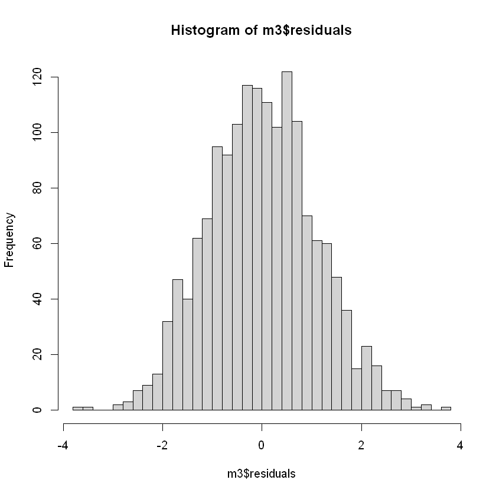

```r
hist(m3$residuals, breaks=50)
```

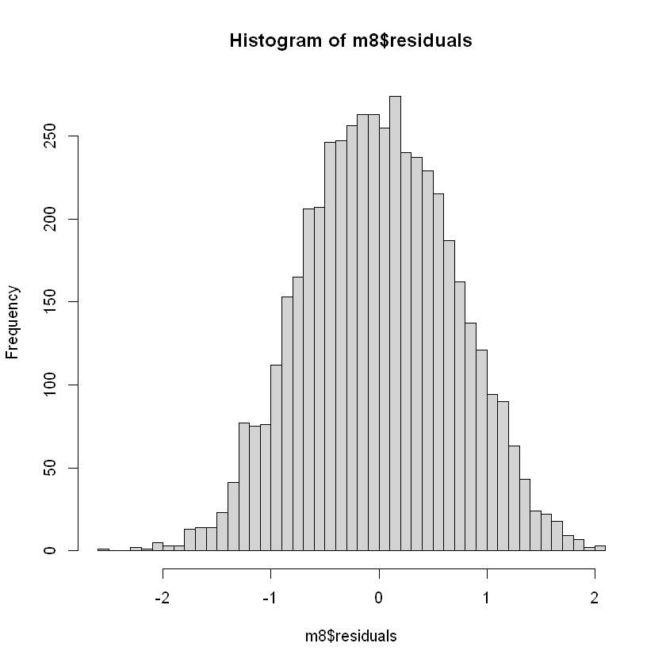

```r
hist(m8$residuals, breaks=50)
```

**While both histograms have a bell-shaped distribution that is centered around 0, there are a few residuals that are outliers.**

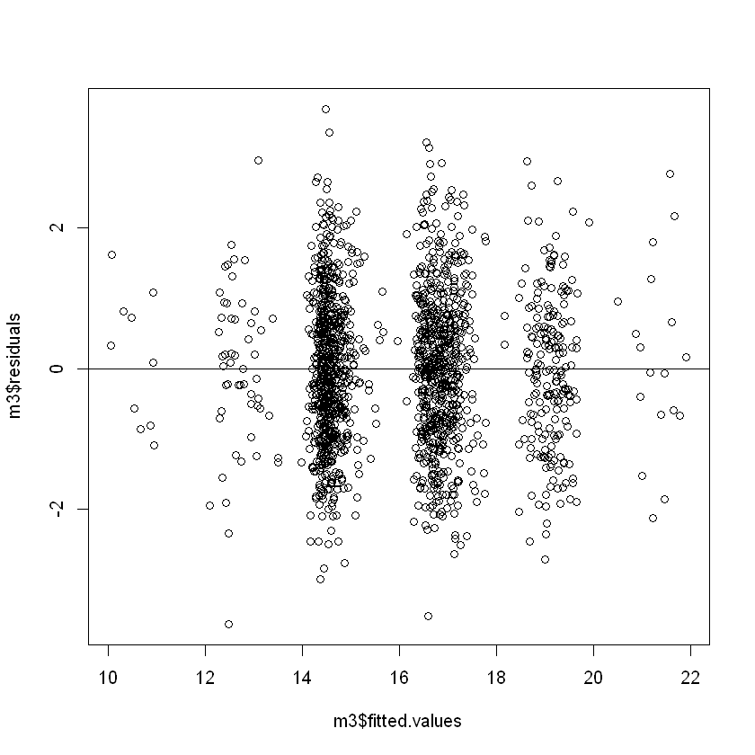

```r
plot(m3$fitted.values, m3$residuals)
abline(h=0)
```

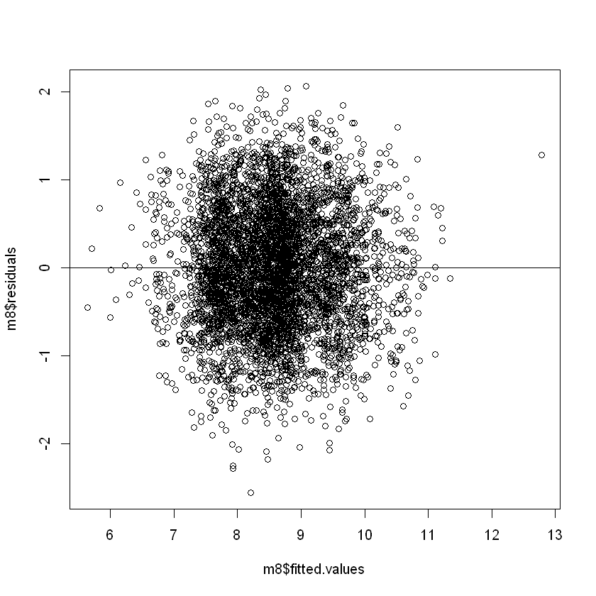

```r
plot(m8$fitted.values, m8$residuals)
abline(h=0)
```

**From the m8 fitted values vs residuals graph I notice that one of the residuals stands out the most that's between 12 and 13 on the x-axis. This suggests that there are outliers and this affects the accuracy of the model. For both graphs there seems to be many points that are concentrated around 0 but, the white wine model (m8) appears to be a slightly better fit.**

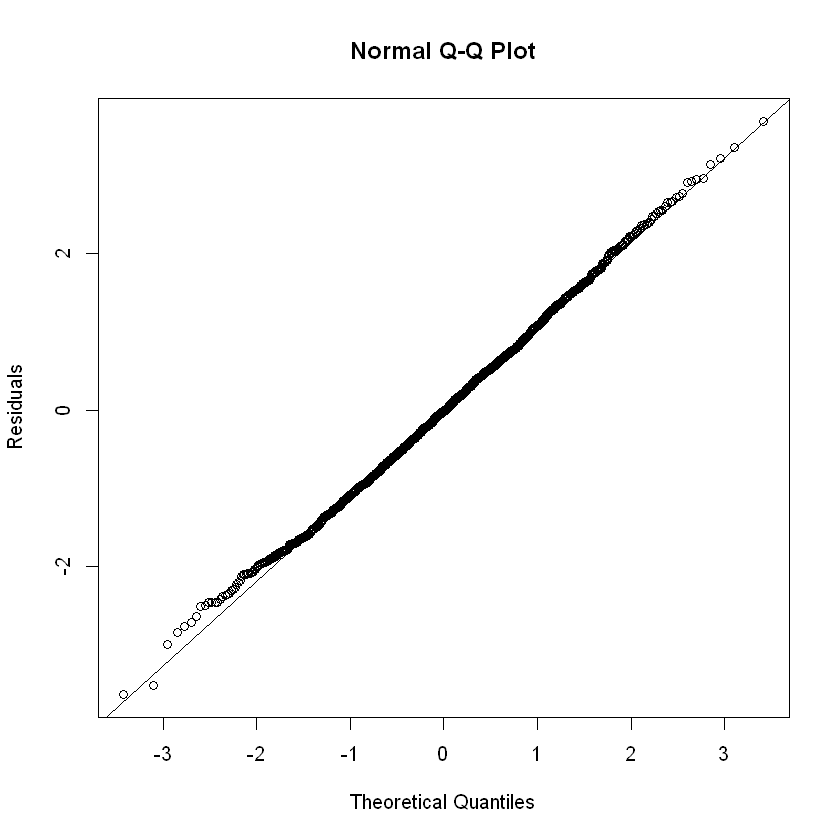

```r
qqnorm(residuals(m3), ylab="Residuals")
qqline(residuals(m3))
```

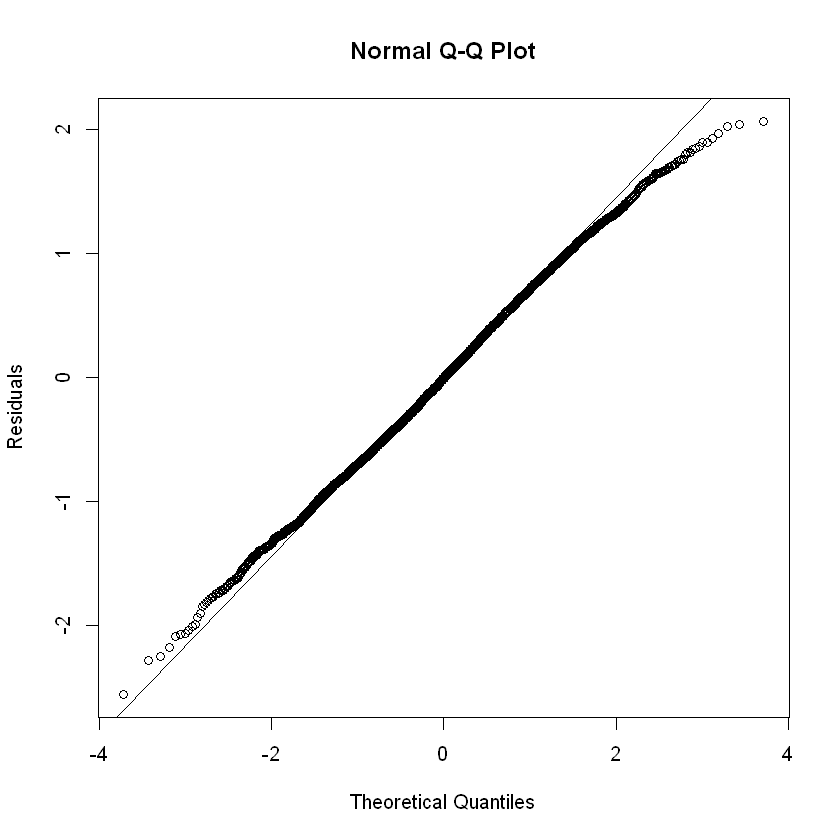

```r
qqnorm(residuals(m8), ylab="Residuals")
qqline(residuals(m8))
```

```r
cor(red)
```

A matrix: 13 × 13 of type dbl

|  | fixed.acidity | volatile.acidity | citric.acid | residual.sugar | chlorides | free.sulfur.dioxide | total.sulfur.dioxide | density | pH | sulphates | alcohol | quality | price |
| --- | --- | --- | --- | --- | --- | --- | --- | --- | --- | --- | --- | --- | --- |
| fixed.acidity | 1.00000000 | -0.256130895 | 0.67170343 | 0.114776724 | 0.093705186 | -0.153794193 | -0.11318144 | 0.66804729 | -0.68297819 | 0.183005664 | -0.06166827 | 0.12405165 | 0.05173833 |
| volatile.acidity | -0.25613089 | 1.000000000 | -0.55249568 | 0.001917882 | 0.061297772 | -0.010503827 | 0.07647000 | 0.02202623 | 0.23493729 | -0.260986685 | -0.20228803 | -0.39055778 | -0.32333145 |
| citric.acid | 0.67170343 | -0.552495685 | 1.00000000 | 0.143577162 | 0.203822914 | -0.060978129 | 0.03553302 | 0.36494718 | -0.54190414 | 0.312770044 | 0.10990325 | 0.22637251 | 0.15766223 |
| residual.sugar | 0.11477672 | 0.001917882 | 0.14357716 | 1.000000000 | 0.055609535 | 0.187048995 | 0.20302788 | 0.35528337 | -0.08565242 | 0.005527121 | 0.04207544 | 0.01373164 | 0.04081874 |
| chlorides | 0.09370519 | 0.061297772 | 0.20382291 | 0.055609535 | 1.000000000 | 0.005562147 | 0.04740047 | 0.20063233 | -0.26502613 | 0.371260481 | -0.22114054 | -0.12890656 | -0.15327404 |
| free.sulfur.dioxide | -0.15379419 | -0.010503827 | -0.06097813 | 0.187048995 | 0.005562147 | 1.000000000 | 0.66766645 | -0.02194583 | 0.07037750 | 0.051657572 | -0.06940835 | -0.05065606 | -0.06023250 |
| total.sulfur.dioxide | -0.11318144 | 0.076470005 | 0.03553302 | 0.203027882 | 0.047400468 | 0.667666450 | 1.00000000 | 0.07126948 | -0.06649456 | 0.042946836 | -0.20565394 | -0.18510029 | -0.20020560 |
| density | 0.66804729 | 0.022026232 | 0.36494718 | 0.355283371 | 0.200632327 | -0.021945831 | 0.07126948 | 1.00000000 | -0.34169933 | 0.148506412 | -0.49617977 | -0.17491923 | -0.21238575 |
| pH | -0.68297819 | 0.234937294 | -0.54190414 | -0.085652422 | -0.265026131 | 0.070377499 | -0.06649456 | -0.34169933 | 1.00000000 | -0.196647602 | 0.20563251 | -0.05773139 | 0.03014265 |
| sulphates | 0.18300566 | -0.260986685 | 0.31277004 | 0.005527121 | 0.371260481 | 0.051657572 | 0.04294684 | 0.14850641 | -0.19664760 | 1.000000000 | 0.09359475 | 0.25139708 | 0.19133177 |
| alcohol | -0.06166827 | -0.202288027 | 0.10990325 | 0.042075437 | -0.221140545 | -0.069408354 | -0.20565394 | -0.49617977 | 0.20563251 | 0.093594750 | 1.00000000 | 0.47616632 | 0.51470957 |
| quality | 0.12405165 | -0.390557780 | 0.22637251 | 0.013731637 | -0.128906560 | -0.050656057 | -0.18510029 | -0.17491923 | -0.05773139 | 0.251397079 | 0.47616632 | 1.00000000 | 0.84834399 |
| price | 0.05173833 | -0.323331453 | 0.15766223 | 0.040818743 | -0.153274043 | -0.060232495 | -0.20020560 | -0.21238575 | 0.03014265 | 0.191331773 | 0.51470957 | 0.84834399 | 1.00000000 |

```r
new_data<-read.csv("New_Wines.csv")
```

```r
head(new_data)
```

A data.frame: 6 × 13

|  | X <chr> | fixed.acidity <dbl> | volatile.acidity <dbl> | citric.acid <dbl> | residual.sugar <dbl> | chlorides <dbl> | free.sulfur.dioxide <int> | total.sulfur.dioxide <int> | density <dbl> | pH <dbl> | sulphates <dbl> | alcohol <dbl> | quality <int> |
| --- | --- | --- | --- | --- | --- | --- | --- | --- | --- | --- | --- | --- | --- |
| 1 | red_new_1 | 8.1 | 0.34 | 0.50 | 4.2 | 0.070 | 17 | 42 | 0.99810 | 3.25 | 0.91 | 13.1 | 8 |
| 2 | red_new_2 | 7.8 | 0.42 | 0.80 | 1.2 | 0.650 | 9 | 51 | 0.99720 | 3.10 | 1.70 | 9.7 | 6 |
| 3 | red_new_3 | 10.6 | 0.62 | 0.51 | 2.3 | 0.230 | 6 | 17 | 0.99950 | 3.20 | 0.64 | 8.1 | 3 |
| 4 | red_new_4 | 6.9 | 0.57 | 0.00 | 2.8 | 0.081 | 21 | 41 | 0.99518 | 3.41 | 0.52 | 10.8 | 5 |
| 5 | red_new_5 | 8.1 | 0.78 | 0.23 | 2.6 | 0.059 | 5 | 15 | 0.99700 | 3.37 | 0.56 | 11.3 | 5 |
| 6 | red_new_6 | 7.2 | 0.66 | 0.03 | 2.3 | 0.078 | 16 | 86 | 0.99743 | 3.53 | 0.57 | 9.7 | 5 |

```r
m10 <- lm(alcohol ~ quality + fixed.acidity, data = new_data)

df1 <- data.frame(quality = 10, fixed.acidity = 7.4)
prediction_pred<-predict(m10, df1, interval = "prediction", level = 0.9)
```

```r
prediction_pred
```

A matrix: 1 × 3 of type dbl

|  | fit | lwr | upr |
| --- | --- | --- | --- |
| 1 | 14.21822 | 9.340963 | 19.09547 |

```r
confidence_pred<- predict(m1, df1, interval = "confidence", level = 0.9)
```

```r
confidence_pred
```

A matrix: 1 × 3 of type dbl

[output not shown]

Write-up: So, I made several models and decided that m3 was better than the basic intercept model for red wine. When i was doing the summary I saw that the p-value was significant (p-value: < 2.2e-16), the F-statistic was fairly big (F-statistic: 903.4), and for the predictors they all had stars. When I ran the anova function I got a P-value(0.5681494) that failed to reject the null hypothesis. I did the same thing with the white wine data set and ended up selecting m8 since the p-value (0.1383393) failed to reject the null hypothesis. My goal of creating many models was to reduce the amount of predictors so that the model is more simpler. I then decided to compare the two models based on their residuals and made histograms of their residuals. What I got was that the histograms were both bell shaped with a few outlier residuals. I then made a qqplot for both m3 and m8 to check if it matched up with what I got for my histogram and it did. For the qqplots I noticed that both the ends for m8 moved away from the line indicating skewdness and the same went for m3 but it was just for one side (the left). When I did the fitted values and residuals graph for m3 and m8 I saw that m8 had sort of a cloud shape and the points were centered around 0. Another thing I noticed from the m8 fitted values and residual graph was that there was a clear extreme outlier that is between 12 and 13 on the x-axis - this could affect the accuracy of the model. For m8 the predictors that contribute to price are volatile.acidity, residual.sugar, sulphates,chlorides,alcohol and quality. For m3 the predictors that contribute to price are fixed.acidity, residual.sugar, total.sulfur.dioxide, alcohol, and quality. m8 (white wine) and m3 (red wine) had similar predictors like alcohol, quality and resisdual.sugar. For the permutation test I got a value of 0. A 0 means that none of the random permutation produced an F-statistic greater than the observed value. That means there is strong evidence against the null hypothesis.